# Spatial Cluster Detection with SaTScan

- Show All Code
- Hide All Code
- View Source

Spatial Epidemiology

Author

Lehigh University

Published

February 25, 2026

## 1 Learning Objectives

By the end of this lecture you will be able to:

1. Explain the **spatial scan statistic** and its underlying logic
2. Describe the key **input files** required by SaTScan software
3. Configure and run a **purely spatial Poisson scan** in the SaTScan GUI
4. Reproduce an equivalent analysis in **R** using `SpatialEpi` and `rsatscan`
5. Correctly **interpret output**—clusters, relative risk, LLR, and p-values
6. Recognize the **limitations** of circular scan statistics

## 2 The Central Question

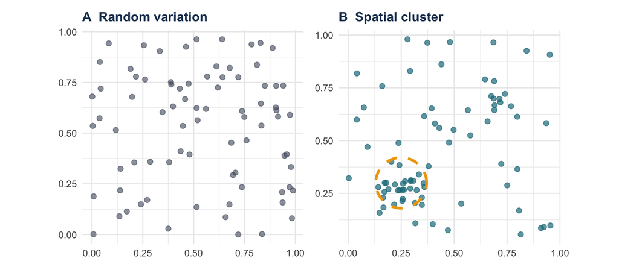

Random variation vs. genuine spatial cluster

```r
library(ggplot2)
library(patchwork)
set.seed(42)

# Panel A: random scatter
df_random <- data.frame(
  x = runif(80), y = runif(80), type = "Random"
)

# Panel B: clustered points
centers <- data.frame(cx = c(0.25, 0.72), cy = c(0.3, 0.7))
df_cluster <- do.call(rbind, lapply(1:nrow(centers), function(i) {
  n <- if (i == 1) 30 else 10
  data.frame(
    x = rnorm(n, centers$cx[i], 0.07),
    y = rnorm(n, centers$cy[i], 0.07),
    type = "Clustered"
  )
}))
df_cluster <- rbind(df_cluster,
  data.frame(x = runif(40), y = runif(40), type = "Clustered"))

theme_map <- theme_minimal(base_size = 11) +
  theme(panel.grid = element_line(color = "grey92"),
        plot.title = element_text(face = "bold", color = "#1A3A5C", size = 12))

p1 <- ggplot(df_random, aes(x, y)) +
  geom_point(color = "#4A5568", alpha = 0.6, size = 2) +
  labs(title = "A  Random variation", x = NULL, y = NULL) +
  coord_fixed() + theme_map

p2 <- ggplot(df_cluster, aes(x, y)) +
  geom_point(color = "#1B7A8A", alpha = 0.7, size = 2) +
  annotate("path",
    x = centers$cx[1] + 0.12 * cos(seq(0, 2*pi, length.out=100)),
    y = centers$cy[1] + 0.12 * sin(seq(0, 2*pi, length.out=100)),
    color = "#F0A500", linewidth = 1.2, linetype = "dashed") +
  labs(title = "B  Spatial cluster", x = NULL, y = NULL) +
  coord_fixed() + theme_map

p1 + p2
```

Disease cases always show some spatial variation. The question is: **is the observed concentration beyond what we’d expect by chance?** SaTScan answers this with a formal statistical test.

## 3 What Is SaTScan?

**SaTScan** (developed by Martin Kulldorff, Harvard) is free software that implements the *spatial scan statistic*—a likelihood ratio test applied to a moving circular window that scans across a study region.

**Note**

**Key facts:** Free download at satscan.org. Available since 1997. Widely used by CDC, state health departments, and in academic research.

### 3.1 Scan types available

| Scan Type | Use Case |
| --- | --- |
| Purely Spatial | Identify geographic clusters; time ignored |
| Purely Temporal | Identify time periods with excess cases; space ignored |
| **Space-Time** | Clusters elevated in both space and time (outbreaks) |
| Prospective Spatial | Real-time surveillance at the current date |
| Spatial Variation in Temporal Trends | Areas where trends diverge from regional average |

### 3.2 Probability models

| Model | Data Needed | When to Use |
| --- | --- | --- |
| **Poisson** | Case counts + population | Most public health applications |
| Bernoulli | Individual case/control indicator | Case-control studies |
| Space-Time Permutation | Case counts only (no population) | Rapid outbreak investigation |
| Normal | Continuous outcome | Environmental exposures, income |
| Multinomial | Multiple disease categories | Comparative disease mapping |

## 4 The Spatial Scan Statistic

### 4.1 Scanning window logic

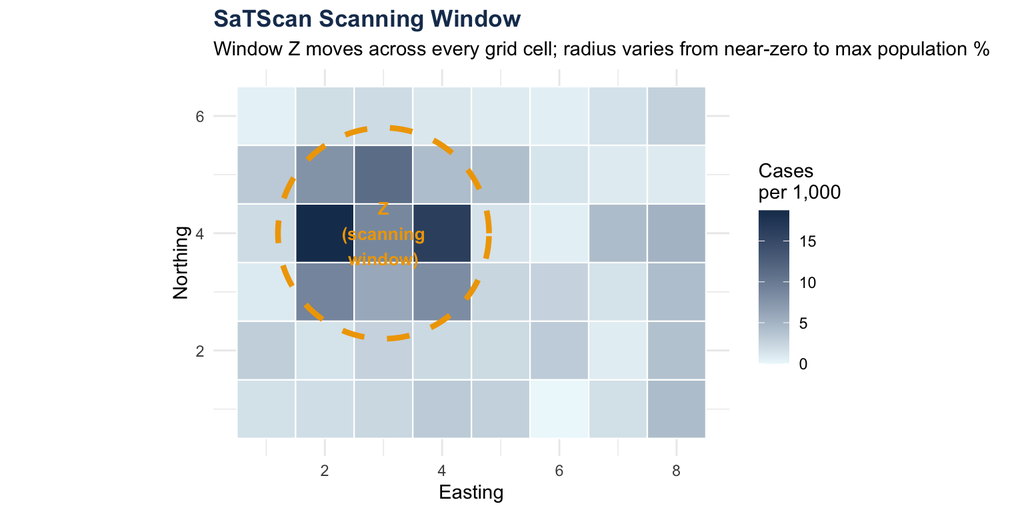

SaTScan imposes circular windows of varying radius at every location, testing each for excess cases.

```r
library(sf)
library(ggplot2)
set.seed(123)

# Simulate a grid of census tracts and case locations
tracts <- expand.grid(x = 1:8, y = 1:6)
tracts$cases <- rpois(nrow(tracts), lambda = 3)
tracts$pop   <- round(runif(nrow(tracts), 800, 2500))

# Inflate cases in a "cluster" region
cluster_mask <- sqrt((tracts$x - 3)^2 + (tracts$y - 4)^2) < 1.8
tracts$cases[cluster_mask] <- tracts$cases[cluster_mask] + rpois(sum(cluster_mask), 12)

# Plot
circle_df <- data.frame(
  x = 3 + 1.8 * cos(seq(0, 2*pi, length.out = 200)),
  y = 4 + 1.8 * sin(seq(0, 2*pi, length.out = 200))
)

ggplot(tracts, aes(x, y)) +
  geom_tile(aes(fill = cases / pop * 1000), color = "white", linewidth = 0.4) +
  geom_path(data = circle_df, aes(x, y),
            color = "#F0A500", linewidth = 1.5, linetype = "dashed") +
  annotate("text", x = 3, y = 4, label = "Z\n(scanning\nwindow)",
           color = "#F0A500", size = 3.5, fontface = "bold") +
  scale_fill_gradient(low = "#EDF8FB", high = "#1A3A5C",
                      name = "Cases\nper 1,000") +
  labs(title = "SaTScan Scanning Window",
       subtitle = "Window Z moves across every grid cell; radius varies from near-zero to max population %",
       x = "Easting", y = "Northing") +
  coord_fixed() +
  theme_minimal(base_size = 11) +
  theme(plot.title = element_text(face = "bold", color = "#1A3A5C"))
```

### 4.2 The likelihood ratio test

For each window **Z**, SaTScan computes the **log-likelihood ratio (LLR)**:

$$\text{LLR}(Z) = \log \left[ \left(\frac{c_Z}{E_Z}\right)^{c_Z} \cdot \left(\frac{C - c_Z}{C - E_Z}\right)^{C - c_Z} \right]
\quad \text{if } c_Z > E_Z, \text{ else } 0$$

where:

- $c_Z$ = observed cases inside window Z
- $E_Z$ = expected cases inside Z (proportional to population)
- $C$ = total cases in the study area

The **test statistic** is $T = \max_Z \, \text{LLR}(Z)$—the window with the highest LLR is the **most likely cluster**.

**Inference via Monte Carlo simulation:**

1. Generate *k* = 999 (or 9,999) datasets by randomly redistributing cases proportional to population
2. Compute T for each simulated dataset
3. $p\text{-value} = \frac{\text{rank of observed } T \text{ among all } k+1 \text{ values}}{k+1}$

**Tip**

**Why Monte Carlo?** SaTScan tests thousands of windows simultaneously. Monte Carlo simulation naturally accounts for this multiple-testing problem—no Bonferroni correction needed.

## 5 SaTScan Software: Input Files

SaTScan requires **three plain-text files**. Location IDs must match across all files.

### 5.1 Case file (`.cas`)

```
location_id   case_count   year [month day]
```

```
34005    12    2020
34007     8    2020
34009     3    2020
34013    21    2020
```

### 5.2 Population file (`.pop`)

```
location_id   population   year
```

```
34005    450000    2020
34007    280000    2020
34009    120000    2020
34013    510000    2020
```

### 5.3 Coordinates file (`.geo`)

```
location_id   latitude   longitude
```

```
34005    40.234    -74.678
34007    40.512    -74.321
34009    40.789    -74.123
34013    40.102    -74.891
```

**Warning**

**Common error:** Location IDs must be **identical** across all three files. A mismatch causes SaTScan to drop records silently.

## 6 SaTScan Software: Step-by-Step Walkthrough

> 🖥️ **Live demo opportunity** — walk through the GUI while narrating these steps.

### 6.1 Step 1 — New Session

`File → New Session`

Choose:

- **Analysis type**: Purely Spatial
- **Probability model**: Poisson

### 6.2 Step 2 — Input tab

- Load **Case File**, **Population File**, **Coordinates File**
- Set **Time Precision** (None for purely spatial; Year/Month/Day for temporal)
- Set **Study Period** dates

### 6.3 Step 3 — Analysis tab

- **Max spatial cluster size**: 50% of population at risk (default). Try 25% for sensitivity.
- **Cluster reporting**: Gini coefficient or report up to N secondary clusters
- **High/Low rates**: High rates only for most disease surveillance

### 6.4 Step 4 — Output tab

- Set output file path (`.txt` for text report)
- Enable optional outputs:
  - ✅ **Google Earth (.kml)** — visualize in Google Earth instantly
  - ✅ **ArcGIS (.shp)** — import cluster polygons into QGIS/ArcGIS
  - ✅ **Cluster Information** — full details for every significant cluster

### 6.5 Step 5 — Spatial Window tab

- Default: **Circular**
- Switch to **Elliptic** for geographically elongated regions (river corridors, highway corridors)

### 6.6 Step 6 — Run

Click **Run**. Open the `.txt` output file. Results list:

1. **Most Likely Cluster** — highest LLR
2. **Secondary Clusters** — next highest LLR clusters that don’t overlap the most likely cluster

## 7 Reading SaTScan Output

A typical SaTScan text output section looks like this:

```
MOST LIKELY CLUSTER
-------------------
1. Location IDs included: 34005 34007 34013 34015
   Coordinates / radius:  (40.38 N, 74.51 W) / 18.3 km
   Population:            1,240,000
   Cases:                 87
   Expected cases:        43.2
   Annual cases / 100,000: 14.3
   Observed / expected:   2.01
   Log likelihood ratio:  27.58
   P-value:               0.001

SECONDARY CLUSTERS
------------------
2. ...
```

### 7.1 Key metrics explained

| Metric | Meaning |
| --- | --- |
| **Center & Radius** | Geographic center and size of the cluster window |
| **Observed (O)** | Actual case count inside the window |
| **Expected (E)** | Cases expected under the null (proportional to pop.) |
| **O / E** | **Relative Risk** — how many times higher than background |
| **LLR** | Log-likelihood ratio; larger = stronger cluster signal |
| **P-value** | Proportion of MC simulations with T ≥ observed T |

**Tip**

**Rule of thumb:** O/E > 1.5 with p < 0.05 is commonly used as a threshold for further investigation, but context always matters.

## 8 R Implementation: SpatialEpi Package

The `SpatialEpi` package provides a pure-R implementation via `kulldorff()` — no external executable required.

### 8.1 Setup and data

```r
# Install if needed:
# install.packages(c("SpatialEpi", "sf", "tmap", "dplyr"))

library(SpatialEpi)
library(sf)
library(tmap)
library(dplyr)

# Load the NY leukemia dataset (ships with SpatialEpi)
data(NYleukemia)

# Examine structure
glimpse(NYleukemia$data)
```

```
Rows: 281
Columns: 3
$ censustract.FIPS <fct> 36007000100, 36007000200, 36007000300, 36007000400, 3…
$ cases            <dbl> 3.08284, 4.08331, 1.08750, 1.06515, 3.06017, 1.06386,…
$ population       <dbl> 3540, 3560, 3739, 2784, 2571, 2729, 3952, 993, 1908, …
```

```r
# Geographic coordinates of census tract centroids
head(NYleukemia$geo)
```

```
  censustract.FIPS         x        y
1      36007000100 -75.94087 42.10782
2      36007000200 -75.93118 42.11099
3      36007000300 -75.92011 42.11738
4      36007000400 -75.89749 42.11801
5      36007000500 -75.90269 42.10872
6      36007000600 -75.88943 42.11400
```

```r
# Case and population data
head(NYleukemia$data)
```

```
  censustract.FIPS   cases population
1      36007000100 3.08284       3540
2      36007000200 4.08331       3560
3      36007000300 1.08750       3739
4      36007000400 1.06515       2784
5      36007000500 3.06017       2571
6      36007000600 1.06386       2729
```

### 8.2 Compute expected counts

```r
# Expected cases under null hypothesis (population-proportional)
pop      <- NYleukemia$data$population
cases    <- NYleukemia$data$cases

expected <- expected(population = pop,
                     cases      = cases,
                     n.strata   = 1)

# Quick sanity check: sum(expected) should equal sum(cases)
cat("Total observed cases:", sum(cases), "\n")
```

```
Total observed cases: 591.9998
```

```r
cat("Total expected cases:", round(sum(expected), 1), "\n")
```

```
Total expected cases: 592
```

### 8.3 Run the Kulldorff scan

```r
# NYleukemia$geo columns: (FIPS, longitude, latitude) — use positions 2:3
# latlong2grid() expects a data.frame with (longitude, latitude) as cols 1 and 2
geo <- latlong2grid(NYleukemia$geo[, 2:3])

# Merge the 4 surrounded tracts into their surrounding tracts
# (standard pre-processing per SpatialEpi documentation)
remove_tracts <- NYleukemia$surrounded
add_tracts    <- NYleukemia$surrounding

pop_adj   <- pop
cases_adj <- cases
pop_adj[add_tracts]   <- pop_adj[add_tracts]   + pop_adj[remove_tracts]
cases_adj[add_tracts] <- cases_adj[add_tracts] + cases_adj[remove_tracts]
pop_adj   <- pop_adj[-remove_tracts]
cases_adj <- cases_adj[-remove_tracts]
geo_adj   <- geo[-remove_tracts, ]

expected_adj <- expected(population = pop_adj, cases = cases_adj, n.strata = 1)

# Run spatial scan statistic
# pop.upper.bound = 0.5 means maximum cluster = 50% of population
set.seed(42)
result <- kulldorff(
  geo              = geo_adj,
  cases            = cases_adj,
  population       = pop_adj,
  expected.cases   = expected_adj,
  pop.upper.bound  = 0.5,
  n.simulations    = 999,
  alpha.level      = 0.05,
  plot             = FALSE
)
```

### 8.4 Inspect results

```r
# Most likely cluster
mlc <- result$most.likely.cluster
cat("Most Likely Cluster\n")
```

```
Most Likely Cluster
```

```r
cat("-------------------\n")
cat("Number of tracts:", length(mlc$location.IDs.included), "\n")
```

```
Number of tracts: 30
```

```r
cat("Observed cases:", sum(cases_adj[mlc$location.IDs.included]), "\n")
```

```
Observed cases: 108.7639
```

```r
cat("Expected cases:", round(mlc$expected.cases, 2), "\n")
```

```
Expected cases: 66.1
```

```r
cat("O/E ratio (Relative Risk):", round(mlc$SMR, 2), "\n")
```

```
O/E ratio (Relative Risk): 1.65
```

```r
cat("Log-likelihood ratio:", round(mlc$log.likelihood.ratio, 3), "\n")
```

```
Log-likelihood ratio: 13.282
```

```r
cat("P-value:", mlc$p.value, "\n")
```

```
P-value: 0.001
```

```r
# Secondary clusters
cat("\nSecondary clusters found:", length(result$secondary.clusters), "\n")
```

```
Secondary clusters found: 1
```

```r
if (length(result$secondary.clusters) > 0) {
  sc <- result$secondary.clusters[[1]]
  cat("  Cluster 2 — LLR:", round(sc$log.likelihood.ratio, 3),
      " | p =", sc$p.value,
      " | O/E =", round(sc$SMR, 2), "\n")
}
```

```
  Cluster 2 — LLR: 8.5  | p = 0.028  | O/E = 1.95
```

### 8.5 Map the clusters

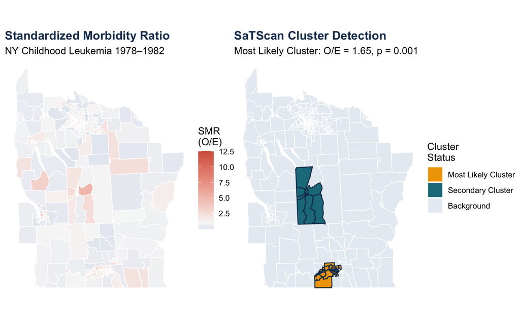

NY Leukemia: most likely cluster (orange fill) identified by Kulldorff spatial scan.

```r
library(sp)

# Build adjusted SpatialPolygons — remove the 4 surrounded tracts to match kulldorff run
sp_adj <- SpatialPolygons(
  NYleukemia$spatial.polygon@polygons[-remove_tracts],
  proj4string = CRS("+proj=longlat +ellps=WGS84")
)

# Convert to sf and attach attributes
ny_sf <- st_as_sf(sp_adj)
ny_sf$cases    <- cases_adj
ny_sf$pop      <- pop_adj
ny_sf$expected <- expected_adj
ny_sf$SMR      <- cases_adj / expected_adj

# Flag cluster membership
ny_sf$cluster_status <- "Background"
ny_sf$cluster_status[mlc$location.IDs.included] <- "Most Likely Cluster"
if (length(result$secondary.clusters) > 0) {
  ny_sf$cluster_status[
    result$secondary.clusters[[1]]$location.IDs.included] <- "Secondary Cluster"
}
ny_sf$cluster_status <- factor(ny_sf$cluster_status,
  levels = c("Most Likely Cluster", "Secondary Cluster", "Background"))

# Map 1: SMR choropleth
p_smr <- ggplot(ny_sf) +
  geom_sf(aes(fill = SMR), color = "white", linewidth = 0.3) +
  scale_fill_gradient2(low = "#2166AC", mid = "#F7F7F7", high = "#D6604D",
                       midpoint = 1, name = "SMR\n(O/E)") +
  labs(title = "Standardized Morbidity Ratio",
       subtitle = "NY Childhood Leukemia 1978–1982") +
  theme_void(base_size = 11) +
  theme(plot.title = element_text(face = "bold", color = "#1A3A5C"))

# Map 2: cluster detection results
cluster_colors <- c("Most Likely Cluster" = "#F0A500",
                    "Secondary Cluster"   = "#1B7A8A",
                    "Background"          = "#E8EDF2")

p_cluster <- ggplot(ny_sf) +
  geom_sf(aes(fill = cluster_status), color = "white", linewidth = 0.3) +
  geom_sf(data = ny_sf[ny_sf$cluster_status != "Background", ],
          fill = NA, color = "#1A3A5C", linewidth = .5) +
  scale_fill_manual(values = cluster_colors, name = "Cluster\nStatus") +
  labs(title = "SaTScan Cluster Detection",
       subtitle = paste0("Most Likely Cluster: O/E = ",
                         round(mlc$SMR, 2), ", p = ", mlc$p.value)) +
  theme_void(base_size = 11) +
  theme(plot.title = element_text(face = "bold", color = "#1A3A5C"))

library(patchwork)
p_smr + p_cluster
```

## 9 R Implementation: rsatscan Package

For larger datasets or when you need SaTScan’s full feature set, `rsatscan` calls the SaTScan executable from R, giving you a fully reproducible workflow.

```r
# Requires SaTScan installed and rsatscan package
# install.packages("rsatscan")
library(rsatscan)

# ── 1. Reset options and write parameter file ──
ss.options(reset = TRUE)

# ── 2. Configure analysis parameters ──
ss.options(list(
  CaseFile              = "cases.cas",
  PopulationFile        = "pop.pop",
  CoordinatesFile       = "geo.geo",
  CoordinatesType       = 1,   # 1 = lat/lon
  AnalysisType          = 1,   # 1 = Purely Spatial
  ModelType             = 0,   # 0 = Poisson
  ScanAreas             = 1,   # 1 = High rates
  TimeAggregationUnits  = 3,   # 3 = Year
  MaxSpatialSizeInPopulationAtRisk = 50,
  MonteCarloReps        = 999,
  ResultsFile           = "output.txt",
  OutputShapefiles      = "y",          # Write .shp files
  OutputGoogleEarthKML  = "y"           # Write .kml file
))

# ── 3. Write input files from R data frames ──
write.cas(casefile,  tempdir(), "cases")
write.pop(popfile,   tempdir(), "pop")
write.geo(geofile,   tempdir(), "geo")

# ── 4. Run SaTScan ──
result <- satscan(
  prmlocation = tempdir(),
  prmfilename = "analysis",
  sslocation  = "/path/to/SaTScan"  # path to SaTScan executable
)

# ── 5. Examine results ──
summary(result)
result$col         # cluster information data frame
result$geo         # cluster geometry for mapping
```

**Note**

**Tip:** `rsatscan` returns results as R data frames, making it easy to pipe cluster results directly into `ggplot2` or `tmap` for publication-quality maps. Set `sslocation` to wherever SaTScan is installed on your machine (e.g., `"C:/Program Files/SaTScan"` on Windows).

## 10 Space-Time Analysis: Detecting Outbreaks

For outbreak detection, use the **Space-Time Permutation** model (no population denominator needed).

```r
# Space-Time Permutation in rsatscan
ss.options(list(
  AnalysisType          = 3,   # 3 = Space-Time
  ModelType             = 2,   # 2 = Space-Time Permutation
  TimeAggregationUnits  = 2,   # 2 = Month
  TimeAggregationLength = 1,
  MaxTemporalSize       = 50,  # Max cluster spans 50% of study period
  MaxSpatialSizeInPopulationAtRisk = 25
))
```

### 10.1 What to look for in space-time output

```
MOST LIKELY CLUSTER
Coordinates:  (39.95 N, 75.17 W) / 3.2 km
Time frame:   2023/3 to 2023/5  (3 months)
Cases:        47    Expected: 12.4
O/E:          3.79
P-value:      0.001
```

A tight geographic radius **plus** a short time window = strong outbreak signal.

## 11 Assumptions, Limitations & Pitfalls

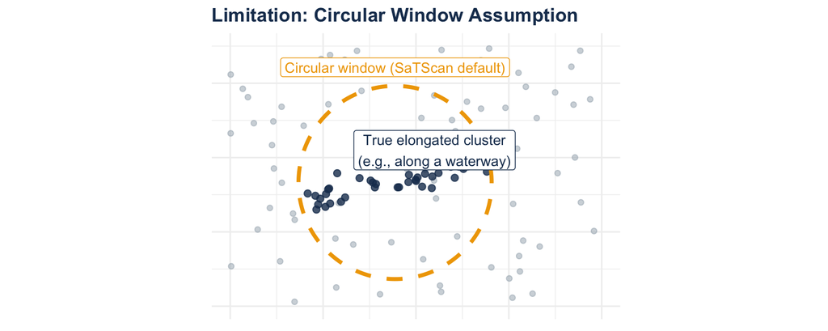

Circular windows may poorly represent elongated or irregular true cluster shapes.

```r
library(ggplot2)

# Show circular window vs. irregular true cluster
set.seed(99)
# True elongated cluster (along a river/road)
true_cluster <- data.frame(
  x = c(rnorm(40, mean = seq(2, 7, length.out = 40), sd = 0.4)),
  y = c(rnorm(40, mean = seq(3, 3.8, length.out = 40), sd = 0.25))
)
background <- data.frame(
  x = runif(80, 0, 10), y = runif(80, 0, 7)
)

# Fitted circular window (best fit circle — will miss edges)
cx <- mean(true_cluster$x); cy <- mean(true_cluster$y)
r  <- 2.6

circle_fit <- data.frame(
  x = cx + r * cos(seq(0, 2*pi, length.out = 200)),
  y = cy + r * sin(seq(0, 2*pi, length.out = 200))
)

ggplot() +
  geom_point(data = background, aes(x, y), color = "#A0ADB8", alpha = 0.5, size = 1.5) +
  geom_point(data = true_cluster, aes(x, y), color = "#1A3A5C", size = 2, alpha = 0.8) +
  geom_path(data = circle_fit, aes(x, y), color = "#F0A500",
            linewidth = 1.3, linetype = "dashed") +
  annotate("label", x = cx, y = cy + r + 0.5,
           label = "Circular window (SaTScan default)",
           color = "#F0A500", size = 3.5, fill = "white") +
  annotate("label", x = 5.5, y = 4.2,
           label = "True elongated cluster\n(e.g., along a waterway)",
           color = "#1A3A5C", size = 3.5, fill = "white") +
  coord_fixed(xlim = c(0, 10), ylim = c(0, 7)) +
  theme_minimal(base_size = 11) +
  labs(title = "Limitation: Circular Window Assumption",
       x = NULL, y = NULL) +
  theme(plot.title = element_text(face = "bold", color = "#1A3A5C"),
        axis.text = element_blank(), panel.grid = element_line(color = "grey94"))
```

### 11.1 Key limitations to discuss with students

| Issue | Description | Mitigation |
| --- | --- | --- |
| **Circular windows** | Real clusters are rarely circular | Use elliptic scan or FleXScan |
| **Max cluster size** | 50% default may catch multi-cluster noise | Sensitivity analysis at 25%, 50% |
| **Edge effects** | Boundary clusters are truncated | Add buffer zone around study area |
| **No covariates** | Cannot adjust for age, SES, race | Stratify or use Bayesian alternatives |
| **Population data** | Poisson model needs accurate denominator | Use most recent ACS; interpolate if needed |
| **Ecological fallacy** | Area-level ≠ individual-level inference | Be explicit: clusters guide investigation, not causation |
| **Reporting bias** | Significant clusters tend to get published | Report all results; pre-register analyses |

**Warning**

**Critical point:** A statistically significant SaTScan cluster is evidence of geographic concentration of disease — it is **not proof of cause**. Clusters always require follow-up with exposure data, contextual knowledge, and epidemiologic investigation.

## 12 SaTScan vs. Other Methods

| Method | Core Approach | Strengths | Limitations |
| --- | --- | --- | --- |
| **SaTScan** | Moving circular window + LLR | Formal inference, p-values, free software | Circular window; no covariate adjustment |
| **Local Moran’s I (LISA)** | Local spatial autocorrelation | Exploratory; identifies hot/cold spots | No formal cluster test; sensitive to scale |
| **Getis-Ord Gi*** | Z-score of local weighted mean | Continuous surface; detects high-value areas | Assumes spatial stationarity |
| **Knox Test** | Space-time proximity pairs | Outbreak investigation | Requires threshold parameters |
| **KDE** | Smoothed density surface | Visual and intuitive | Subjective bandwidth; no inference |
| **Bayesian (BYM)** | Hierarchical spatial model | Smooths small-area rates; covariate adjustment | Complex MCMC; harder to explain |

## 13 Worked Example Summary

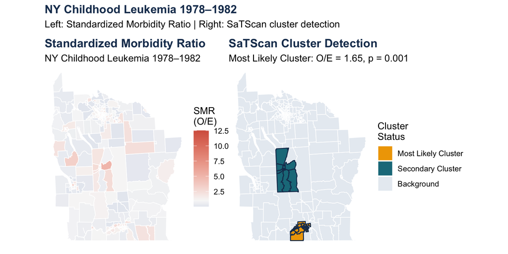

Final output: SMR and cluster detection side by side for the NY leukemia dataset.

```r
# Already computed above — re-display the comparison maps
p_smr + p_cluster + plot_annotation(
  title    = "NY Childhood Leukemia 1978–1982",
  subtitle = "Left: Standardized Morbidity Ratio | Right: SaTScan cluster detection",
  theme    = theme(plot.title = element_text(face = "bold", color = "#1A3A5C", size = 13))
)
```

**Interpretation of these results:**

- The **most likely cluster** contains census tracts with O/E = 1.65, meaning approximately 65% more childhood leukemia cases than expected.
- The p-value is 0.001, suggesting this cluster is unlikely to arise by chance under the null hypothesis of spatial randomness.
- This cluster (Binghamton, NY area) prompted further investigation into proximity to nuclear power facilities and industrial waste sites — though causation requires additional study.

## 14 Quick Reference: Common Workflow

```r
# ─── Complete workflow: SpatialEpi::kulldorff() ───────────────────────────

library(SpatialEpi)

# 1. Load / prepare data
#    geo    = data.frame with lat and lon (one row per area)
#    cases  = integer vector (cases per area)
#    pop    = integer vector (population per area)

# 2. Compute expected
expected <- expected(population = pop, cases = cases, n.strata = 1)

# 3. Convert coordinates
# latlong2grid() expects 2-column data.frame: (longitude, latitude)
# For NYleukemia: latlong2grid(NYleukemia$geo[, 2:3])
geo_grid <- latlong2grid(geo[, c("longitude", "latitude")])

# 4. Run scan
result <- kulldorff(
  geo              = geo_grid,
  cases            = cases,
  population       = pop,
  expected.cases   = expected,
  pop.upper.bound  = 0.50,       # max 50% of population
  n.simulations    = 999,
  alpha.level      = 0.05,
  plot             = FALSE
)

# 5. Extract results
result$most.likely.cluster$SMR              # Relative Risk
result$most.likely.cluster$p.value          # P-value
result$most.likely.cluster$location.IDs.included  # Which areas?

# 6. Map
# Flag cluster IDs in your sf object and use ggplot2 / tmap
```

## 15 Summary

**NoteKey Take-Aways**

1. **SaTScan** uses a circular scanning window and a log-likelihood ratio test, with p-values from Monte Carlo simulation.
2. **Three input files** are required: case counts, population, and geographic coordinates — all as plain text with matching location IDs.
3. **Choose your model:** Poisson for counts with a denominator; Bernoulli for case-control; Space-Time Permutation when no population data is available.
4. **In R**, use `SpatialEpi::kulldorff()` for a self-contained analysis, or `rsatscan` to call the full SaTScan executable programmatically.
5. **Interpret carefully:** O/E gives relative risk; p-value tests against spatial randomness. A significant cluster is the start of an investigation, not a conclusion.
6. **Know the limits:** circular windows, no covariate adjustment, ecological inference only.

## 16 Resources

- **SaTScan software & manual:** https://www.satscan.org
- **Kulldorff (1997)** original paper: *Communications in Statistics — Theory and Methods*, 26(6):1481–1496
- **R packages:**
  - `SpatialEpi` — `install.packages("SpatialEpi")`
  - `rsatscan` — `install.packages("rsatscan")`
- **Waller & Gotway (2004):** *Applied Spatial Statistics for Public Health Data* (Wiley) — Chapter 7
- **CDC SaTScan resources:** https://www.cdc.gov/ophss/csels/dsepd/index.html

*Spatial Epidemiology — Lehigh University — February 2026*